# Bike Sharing

Aga, Karla, Nisse, Ole

2023-12-16

# Abstract

[figure not shown]

“*Bikesharing contributes to the advent of more sustainable transportation in cities around the globe.*” (Béland 2014). Bikesharing programs are designed to provide short-term bicycle rental in stations dispersed throughout the cities and located near public transportation hubs (Béland 2014). They have numerous environmental and health benefits, such as reducing congestion, complementing other forms of public transportation and encouraging exercise (Béland 2014). Additionally, accessible bike rental has a lower barrier of entry than purchasing your own bike and is more convenient for out-of-town commuters.  
In principle bicycles pose a good substitute for car use in urban areas, however, they have certain limitations. Among them is the exposure of cyclists to weather while commuting compared to other means of transportation. It would be intuitive for the number of bike rentals to be dependent on current weather conditions. If that is the case, the extent of that relationship would be important information for the bikesharing companies. Potentially, the information could be a factor in variety if business decisions, including level of pricing or supply for bikes in different seasons.

Operationalization of the RQ:

# References

Béland, D. 2014. *Developing Sustainable Urban Transportation*. *International Journal of Sociology and Social Policy*. Vol. 34. Emerald Group Publishing Limited. https://doi.org/10.1108/IJSSP-07-2013-0072.

# Load data

Data set is acquired from a [machine-learning repository](https://archive.ics.uci.edu/dataset/275/bike+sharing+dataset), which provided us with three files, namely:

- `hour.csv`, hourly data of bike rentals.
- `day.csv`, daily data of bike rentals.
- `README.txt`, providing additional metadata about the file and their data.

```r
library(tidyverse)
library(fastDummies)
library(kableExtra)
library(gridExtra, exclude="combine")
library(lubridate)
library(car)
library(ICC)
```

```r
# Source hourly data for model
source_data <- read.csv("../data/hour.csv", header = TRUE, sep = ",") %>%
  as_tibble()

# Extra daily data for EDA
day_df <- read.csv("../data/hour.csv", header = TRUE, sep = ",") %>%
  as_tibble()

# Clone source
data <- source_data

head(data)
```

| instant | dteday | season | yr | mnth | hr | holiday | weekday | workingday | weathersit | temp | atemp | hum | windspeed | casual | registered | cnt |
| --- | --- | --- | --- | --- | --- | --- | --- | --- | --- | --- | --- | --- | --- | --- | --- | --- |
| 1 | 2011-01-01 | 1 | 0 | 1 | 0 | 0 | 6 | 0 | 1 | 0.24 | 0.2879 | 0.81 | 0.0000 | 3 | 13 | 16 |
| 2 | 2011-01-01 | 1 | 0 | 1 | 1 | 0 | 6 | 0 | 1 | 0.22 | 0.2727 | 0.80 | 0.0000 | 8 | 32 | 40 |
| 3 | 2011-01-01 | 1 | 0 | 1 | 2 | 0 | 6 | 0 | 1 | 0.22 | 0.2727 | 0.80 | 0.0000 | 5 | 27 | 32 |
| 4 | 2011-01-01 | 1 | 0 | 1 | 3 | 0 | 6 | 0 | 1 | 0.24 | 0.2879 | 0.75 | 0.0000 | 3 | 10 | 13 |
| 5 | 2011-01-01 | 1 | 0 | 1 | 4 | 0 | 6 | 0 | 1 | 0.24 | 0.2879 | 0.75 | 0.0000 | 0 | 1 | 1 |
| 6 | 2011-01-01 | 1 | 0 | 1 | 5 | 0 | 6 | 0 | 2 | 0.24 | 0.2576 | 0.75 | 0.0896 | 0 | 1 | 1 |

We then create a sub-selection of variables that are of interest for our model; these are the control, predictor and outcome variables + variables necessary for EDA and preprocessing.

```r
data <- select(data,
               dteday,
               hr,
               weathersit,
               temp,
               atemp,
               hum,
               windspeed,
               cnt)
```

# Preprocessing & EDA

## Data Cleaning

### Expand `dteday` data

Expand `dteday` data by adding `dt_num` (numeric version of day, day_id so to speak).

```r
# Converts datetime string to numeric with origin offset.
date_to_num <- function(date, offset) {
   as.integer(as.Date(date, "%Y-%m-%d")) - offset
}

# Fetch origin.
dt_offset <- source_data$dteday[1] %>%
  date_to_num(0) - 1


data <- data %>%
  mutate(
    dt_num = date_to_num(dteday, dt_offset)
  )

# Global variable for amount of unique days.
n_days <- n_distinct(data$dteday)
```

### Clustering of `hr` categories

Create clusters for `hr` called `hr_seg`. 24 dummy codes it too much. Can use `ICC`, but requires systematic approach and might result in non-continuous clusters (as in not a single range of hours, e.g. 2, 7, 8).

Instead divide based on relation to outcome variable.

```r
# Shift the `hr` data by 2 and increment the hour 23 for easier binning via the cut function.
data <- data %>%
  mutate(hr_idx = hr + 2)

data$hr_idx[data$hr == 23] <- 1

# Cut the 24 hour entries in 3 categories.
data <- data %>%
  mutate(hr_seg = cut(
    hr_idx,
    breaks = c(0, 8, 16, 24),
    labels = c("night", "morning-noon", "eve")
  ))
```

Check whether segmenting of `hr` is applied correctly by looking at single day data.

```r
# Check output for single day.
data %>%
  filter(dteday == "2011-01-01") %>%
  arrange(hr) %>%
  select(hr, hr_seg) %>%
  head(24)
```

| hr | hr_seg |
| --- | --- |
| 0 | night |
| 1 | night |
| 2 | night |
| 3 | night |
| 4 | night |
| 5 | night |
| 6 | night |
| 7 | morning-noon |
| 8 | morning-noon |
| 9 | morning-noon |

[output cut: 14 more lines]

Segments were chosen based on `hr~cnt` data. Segments needed to be of equal size.

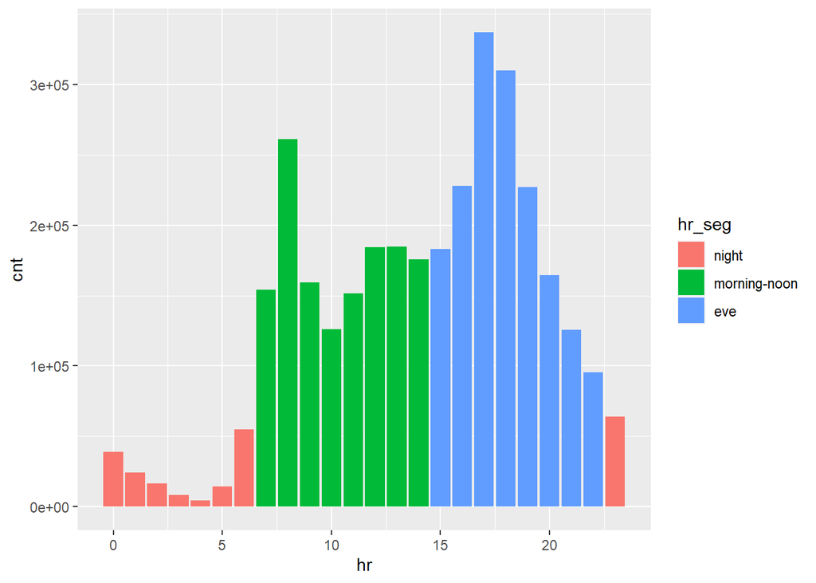

```r
# Create a `mode` function for aggregation.
mode <- function(x) {
    which.max(table(x))
}

# Plot hr~cnt with current segmentation indicator.
data %>%
  group_by(hr, hr_seg) %>%
  summarise(
    cnt = sum(cnt)
  ) %>%
  ggplot(aes(hr, cnt, fill = hr_seg)) +
    geom_bar(stat = "identity")
```

## Summary/stats?

Summary of our data.

```r
summary(data)
```

```
##     dteday                hr          weathersit         temp
##  Length:17379       Min.   : 0.00   Min.   :1.000   Min.   :0.020
##  Class :character   1st Qu.: 6.00   1st Qu.:1.000   1st Qu.:0.340
##  Mode  :character   Median :12.00   Median :1.000   Median :0.500
##                     Mean   :11.55   Mean   :1.425   Mean   :0.497
##                     3rd Qu.:18.00   3rd Qu.:2.000   3rd Qu.:0.660
##                     Max.   :23.00   Max.   :4.000   Max.   :1.000
##      atemp             hum           windspeed           cnt
##  Min.   :0.0000   Min.   :0.0000   Min.   :0.0000   Min.   :  1.0
##  1st Qu.:0.3333   1st Qu.:0.4800   1st Qu.:0.1045   1st Qu.: 40.0
##  Median :0.4848   Median :0.6300   Median :0.1940   Median :142.0
##  Mean   :0.4758   Mean   :0.6272   Mean   :0.1901   Mean   :189.5
##  3rd Qu.:0.6212   3rd Qu.:0.7800   3rd Qu.:0.2537   3rd Qu.:281.0
##  Max.   :1.0000   Max.   :1.0000   Max.   :0.8507   Max.   :977.0
##      dt_num          hr_idx               hr_seg
##  Min.   :  1.0   Min.   : 1.00   night       :5729
##  1st Qu.:185.0   1st Qu.: 7.00   morning-noon:5821
##  Median :367.0   Median :13.00   eve         :5829
##  Mean   :367.2   Mean   :12.54
##  3rd Qu.:549.0   3rd Qu.:19.00
##  Max.   :731.0   Max.   :24.00
```

Data contains 731 unique days, meaning that the entirety of 2011 (365 days) and 2012 (366 days) was recorded.

## Distributions

Distributions of variables.

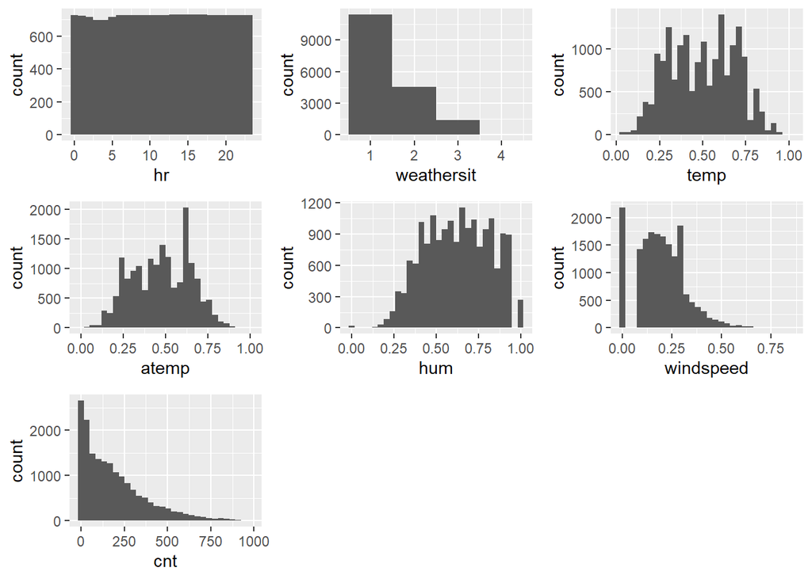

Notice the following:

- Missing records in some `hr` categories.
- Occurrence gap in `windspeed` distribution.
- Category 4 of `weathersit` is barely present. (categorical outlier)

## Outliers

Outlier detection using quantiles.

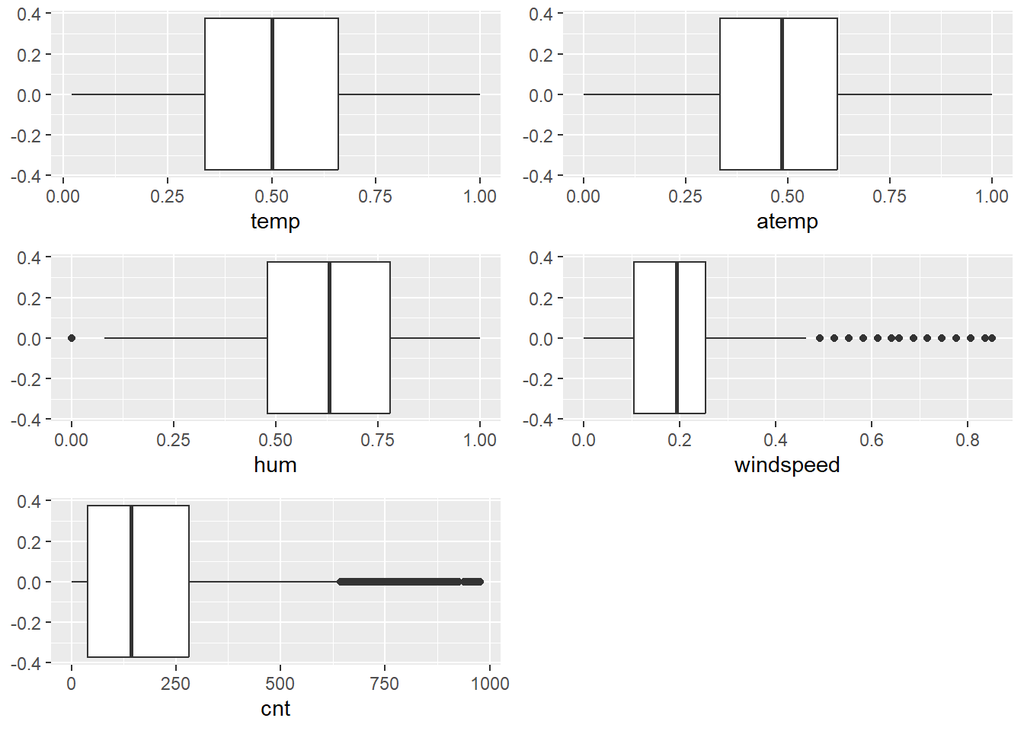

Notice the following:

### Rental count outliers

Large amount of `cnt` outliers is due to low rental count during the night, which shifts the median to a lower value. `hr_seg` acts as moderator, so better to check data displays *per* `hr_seg` cluster.

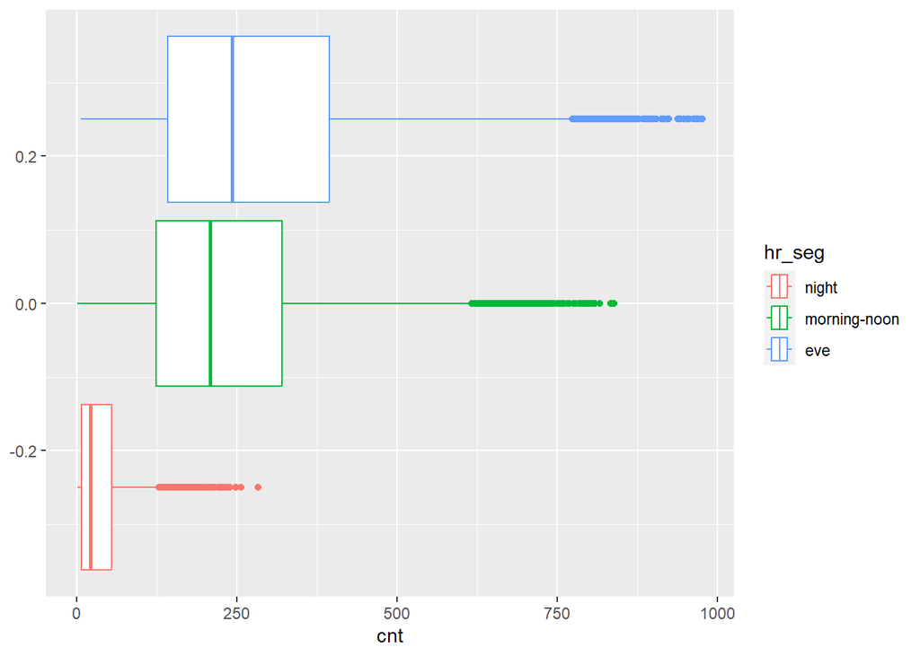

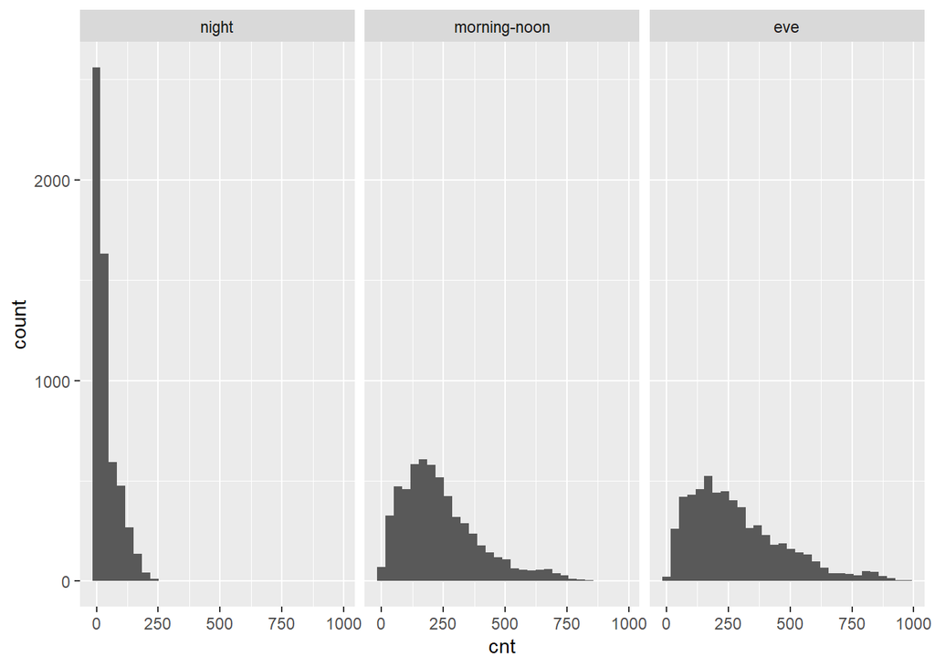

Even then we see that distributions per `hr_seq` are heavily right-skewed, explaining the multitude of outliers.  
Looking at the tail-end of the `cnt` values, these seem to be non-error outliers. Furthermore they seem to be reasonable values due to right-skewness, hence we don’t remove them.

### Windspeed outliers

Again right-skewed, hence large values are seen as outliers. Do notice how there’s gap between 0 values and the first non-zero values, specifically:

```r
data %>%
  group_by(windspeed) %>%
  summarise(n = n()) %>%
  arrange(windspeed) %>%
  head()
```

| windspeed | n |
| --- | --- |
| 0.0000 | 2180 |
| 0.0896 | 1425 |
| 0.1045 | 1617 |
| 0.1343 | 1738 |
| 0.1642 | 1695 |
| 0.1940 | 1657 |

Might be due to sensor threshold for measuring windspeed. In any case, these values fall within the distribution, it is only odd that there’s a small increment between the `0.00` occurences and the values thereafter (e.g. `0.0869`). These might also be possible missing values which are replaced with `0.00`.  
In any case, we cannot know for certain. Since the number of occurrences for `0.00` is in line with neigbouring values, we choose to keep them.

### Humidity outliers

`hum` is left-skewed.

```r
data %>%
  group_by(hum) %>%
  summarise(n = n()) %>%
  arrange(hum) %>%
  head()
```

| hum | n |
| --- | --- |
| 0.00 | 22 |
| 0.08 | 1 |
| 0.10 | 1 |
| 0.12 | 1 |
| 0.13 | 1 |
| 0.14 | 2 |

## Missing data

Check standard NA values. There are none.

```r
anyNA(data)
```

```
## [1] FALSE
```

### Missing records for hour

Some `hr` values seem to have a lower amount of occurrences than others, as can be seen in distribution plot of Distributions

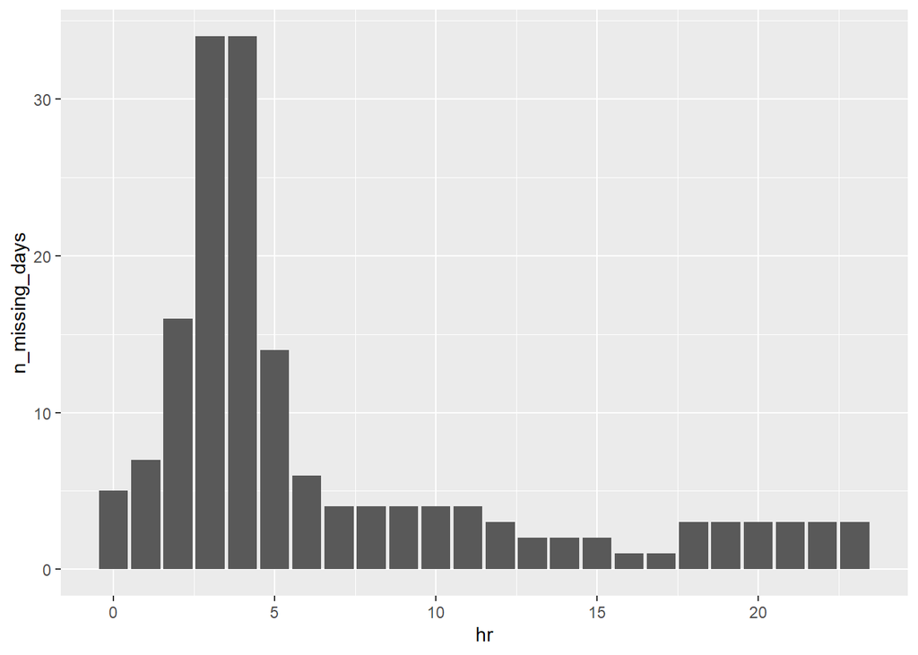

```r
# Count the amount of records per hour.
# Also add a column for amount of *missing* records.
hr_df <- data %>%
  group_by(hr) %>%
  summarise(
    n = n(),
    n_missing_days = n_days - n) # using global variable `n_days`.

ggplot(hr_df, aes(hr, n_missing_days)) +
  geom_bar(stat = "identity")
```

```r
# Create dataframe with amount of missing records per day.
missing_df <- data %>%
  group_by(dteday, dt_num) %>%
  summarise(
    n_records = n(),
    n_missing_records = 24 - n_records
  ) %>%
  filter(n_missing_records > 0) %>%
  arrange(desc(n_missing_records)) %>%
  select(dteday, n_missing_records)

head(missing_df, 10)
```

| dteday | n_missing_records |
| --- | --- |
| 2012-10-29 | 23 |
| 2011-01-27 | 16 |
| 2012-10-30 | 13 |
| 2011-01-18 | 12 |
| 2011-01-26 | 8 |
| 2011-08-28 | 7 |
| 2011-02-22 | 6 |
| 2011-08-27 | 6 |
| 2011-01-03 | 2 |
| 2011-01-11 | 2 |

`n_missing_records` is the amount of missing entries on that particalur day.

## Covariance

### Covariance with predictor `atemp`

Have suspicion that `atemp` might be correlated with `temp`, `windspeed` and `hum`, since it is a combined variable of the three (mayhaps). Justify this:

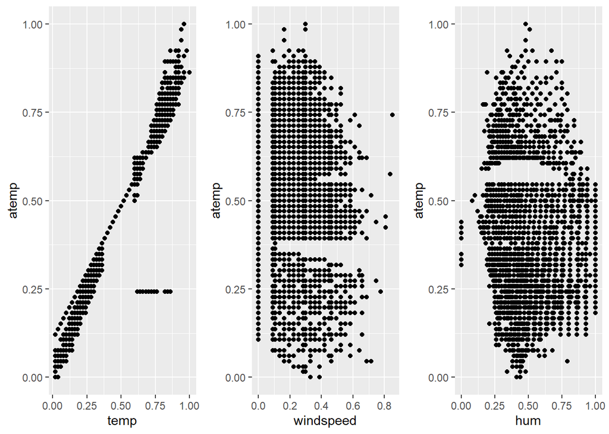

Can conclude that predictor variables `atemp` and `temp` are highly correlated, whilst `hum` and `windspeed` have a weaker relation with `atemp`.

### Covariance with outcome variable `cnt`

Create covariance table of predictor vs outcome variables.

```r
covar_df <- data.frame(
  temp = cor(data$cnt, data$temp),
  hum = cor(data$cnt, data$hum),
  windspeed = cor(data$cnt, data$windspeed),
  weathersit = cor(data$cnt, data$weathersit)
)

covar_df
```

| temp | hum | windspeed | weathersit |
| --- | --- | --- | --- |
| 0.4047723 | -0.3229107 | 0.09323378 | -0.1424261 |

Remark:

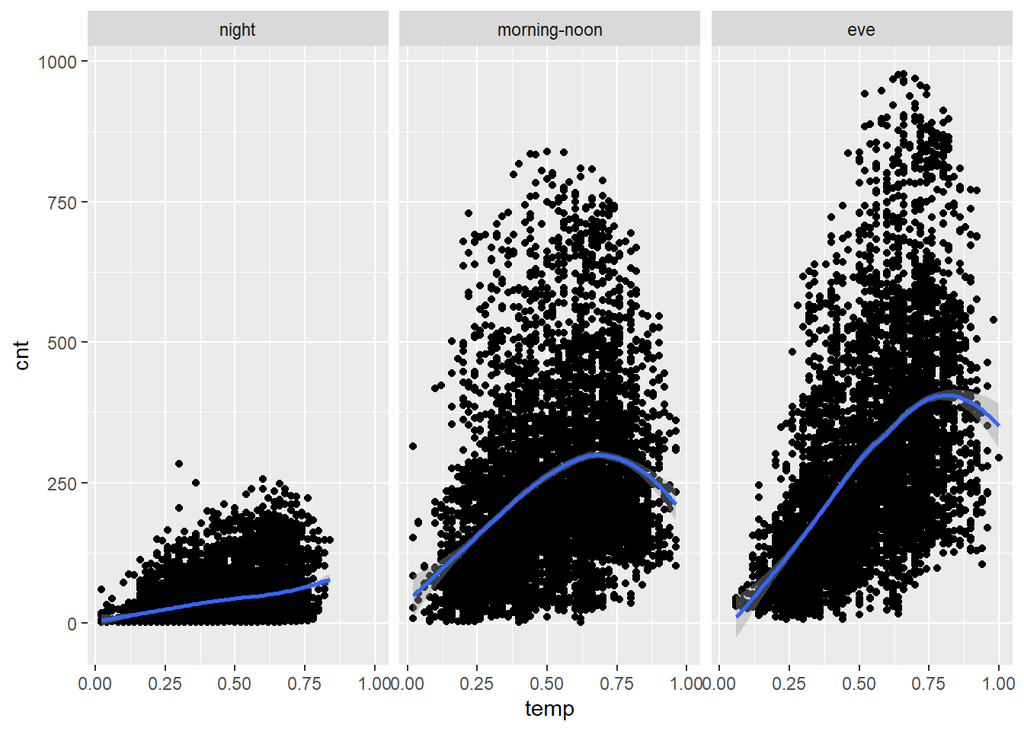

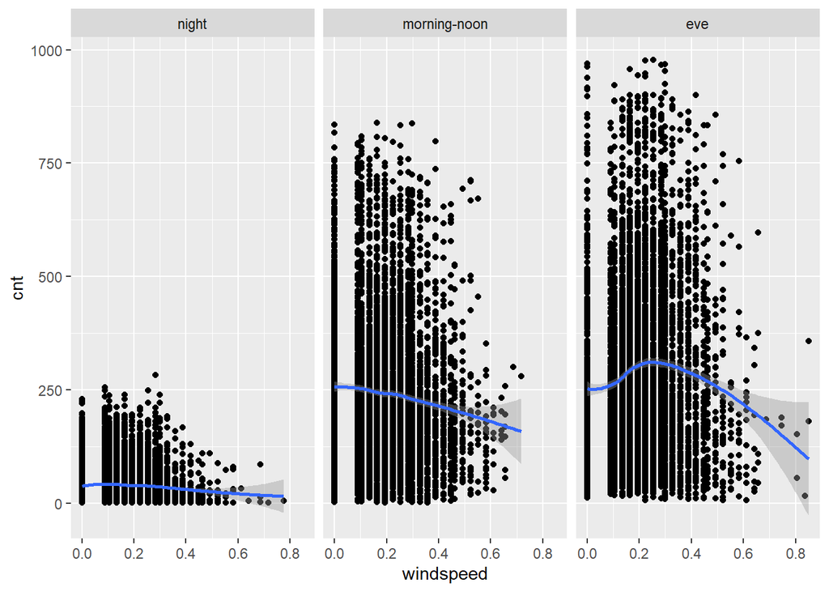

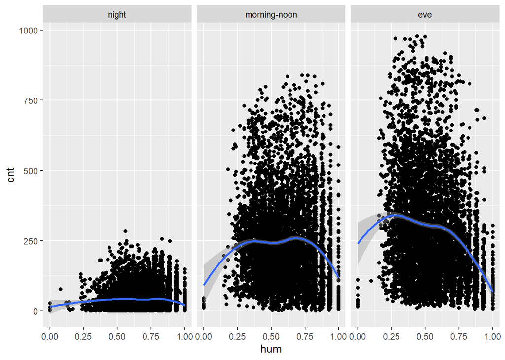

## Data Aggregation

After having created `hr_seq`, we aggregate the data based on both the date (`dteday`) and the hour segments (`hr_seg`. In case of dichotomous variables, we take the `mode` of the variable, with earlier defined function.

```r
# Aggregate over `hr_bin` factor.
data <- data %>%
    group_by(dteday, hr_seg) %>%
    summarize(
        temp = mean(temp),
        atemp = mean(atemp),
        hum = mean(hum),
        windspeed = mean(atemp),
        weathersit = mode(weathersit),
        cnt = sum(cnt)
    )
```

# Model creation & comparison

Later on in Assumptions we concluded a non-linear (higher-order) relation between `hum` and `cnt`. To approximate a linear relation, we’ve transformed the data to `f(x) = x^3`, saved in column `hum3`.

```r
data$hum3 = data$hum^3
```

Create simple and complex models. Order is based on covariance table (high to low).

```r
# Create models.
model1        <- lm(cnt ~ temp, data)
model2        <- lm(cnt ~ temp + hum3, data)
model3        <- lm(cnt ~ temp + hum3 + weathersit, data)
model4        <- lm(cnt ~ temp + hum3 + weathersit + windspeed, data)

# Include moderator for model of choice (#2), for comparison analysis.
model2_mod    <- lm(cnt ~ (temp + hum3)* hr_seg, data)
```

Comparison results table.

```r
RMSE <- function(model) {
  model$residuals^2 %>% mean()
}

comp_df <- data.frame(
  model = c('model1', 'model2', 'model3', 'model4', 'model2_mod'),
  predictors = c('temp', 'temp + hum3', 'temp + hum3 + weathersit', 'temp + hum3 + weathersit + windspeed', 'temp + hum3'),
  moderator = c('', '', '', '', 'hr_seg'),
  AIC = c(AIC(model1), AIC(model2), AIC(model3), AIC(model4), AIC(model2_mod)),
  BIC = c(BIC(model1), BIC(model2), BIC(model3), BIC(model4), BIC(model2_mod)),
  RMSE = c(RMSE(model1), RMSE(model2), RMSE(model3), RMSE(model4), RMSE(model2_mod))
)


comp_df
```

| model | predictors | moderator | AIC | BIC | RMSE |
| --- | --- | --- | --- | --- | --- |
| model1 | temp |  | 36499.60 | 36516.68 | 1010411.2 |
| model2 | temp + hum3 |  | 36005.96 | 36028.73 | 805766.2 |
| model3 | temp + hum3 + weathersit |  | 36007.46 | 36035.92 | 805581.4 |
| model4 | temp + hum3 + weathersit + windspeed |  | 36002.33 | 36036.48 | 802961.4 |
| model2_mod | temp + hum3 | hr_seg | 34050.13 | 34107.05 | 328074.6 |

Anova tests.

```r
# Simple and complex model
anova(model1, model2)
```

|  | Res.Df | RSS | Df | Sum of Sq | F | Pr(>F) |
| --- | --- | --- | --- | --- | --- | --- |
| 1 | 2188 | 2212800571 | NA | NA | NA | NA |
| 2 | 2187 | 1764628072 | 1 | 448172499 | 555.4447 | 1.255498e-109 |

```r
anova(model2, model3)
```

|  | Res.Df | RSS | Df | Sum of Sq | F | Pr(>F) |
| --- | --- | --- | --- | --- | --- | --- |
| 1 | 2187 | 1764628072 | NA | NA | NA | NA |
| 2 | 2186 | 1764223272 | 1 | 404800 | 0.5015764 | 0.4788838 |

```r
anova(model3, model4)
```

|  | Res.Df | RSS | Df | Sum of Sq | F | Pr(>F) |
| --- | --- | --- | --- | --- | --- | --- |
| 1 | 2186 | 1764223272 | NA | NA | NA | NA |
| 2 | 2185 | 1758485546 | 1 | 5737726 | 7.129392 | 0.007639226 |

```r
# Test addition of moderator
anova(model2, model2_mod)
```

|  | Res.Df | RSS | Df | Sum of Sq | F | Pr(>F) |
| --- | --- | --- | --- | --- | --- | --- |
| 1 | 2187 | 1764628072 | NA | NA | NA | NA |
| 2 | 2181 | 718483466 | 6 | 1046144606 | 529.2725 | 0 |

# Assumptions

## Linearity

Small remark, the `car` library with `crPlots` function is not applicable on model with interactions, hence we plot per predictor to check relations.

### `temp`

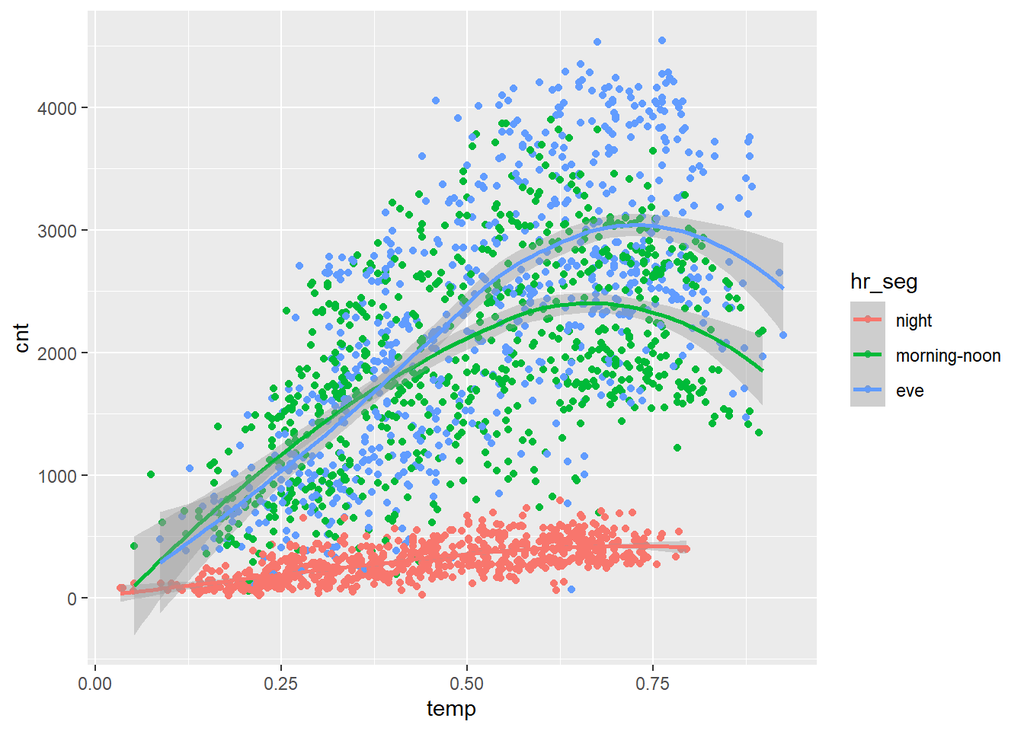

The relationship is not quite linear. It seems that, when the temperature gets too high, people stop renting bikes. The higher temperatures which stop people from renting bikes, do not seem to occur in the night. Therefore, the relationship between temperature and rent count seems linear in the night.

### `hum`

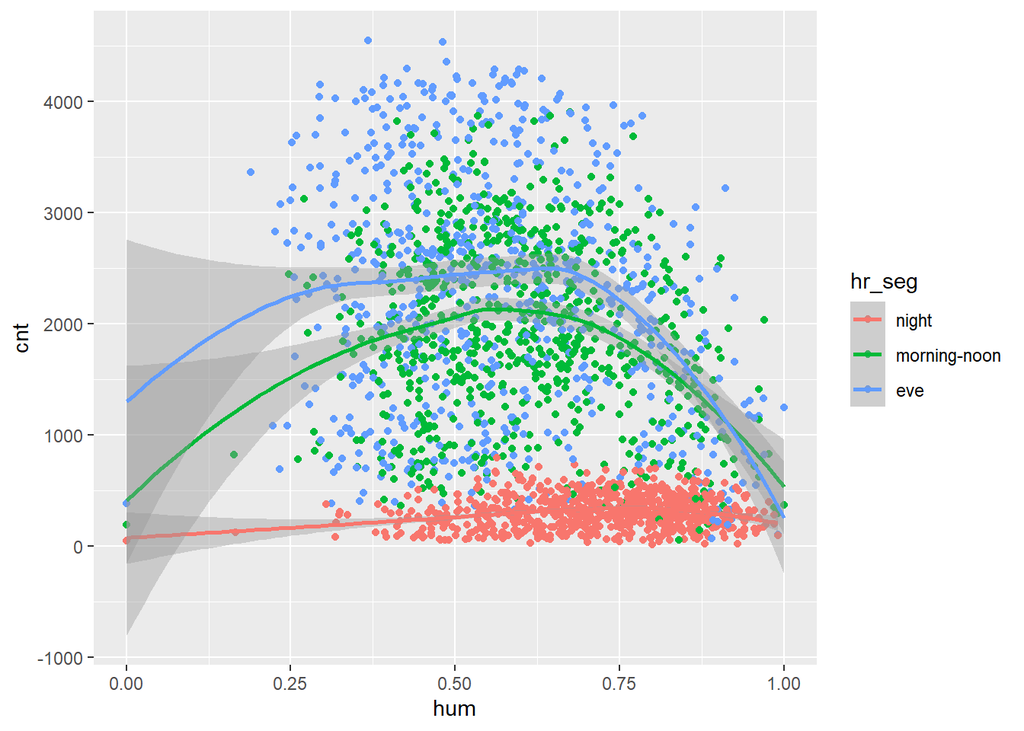

To combat this non-linearity issue, we have transformed the predictor variable `hum` (as mentioned earlier). This does make the interpretation of the model less intuitive.

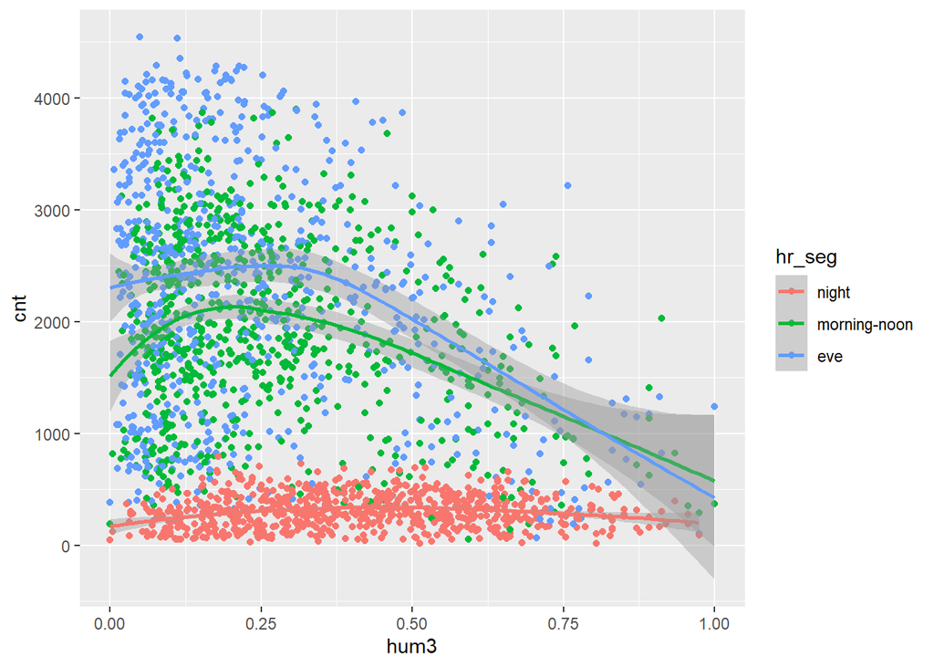

This is the best transformation we could come up with. It’s not perfect, but we’re accepting this as sufficiently linear.

## Full rank predictor matrix

The dataset contains 2190 observations (that is, the dataset after aggregating the data). It only contains 9 variables, including the transformed humidity variable. There are definitely more observations than there are variables.

Next, we need to know whether there is a relationship between the two predictors we are using, temperature and humidity.

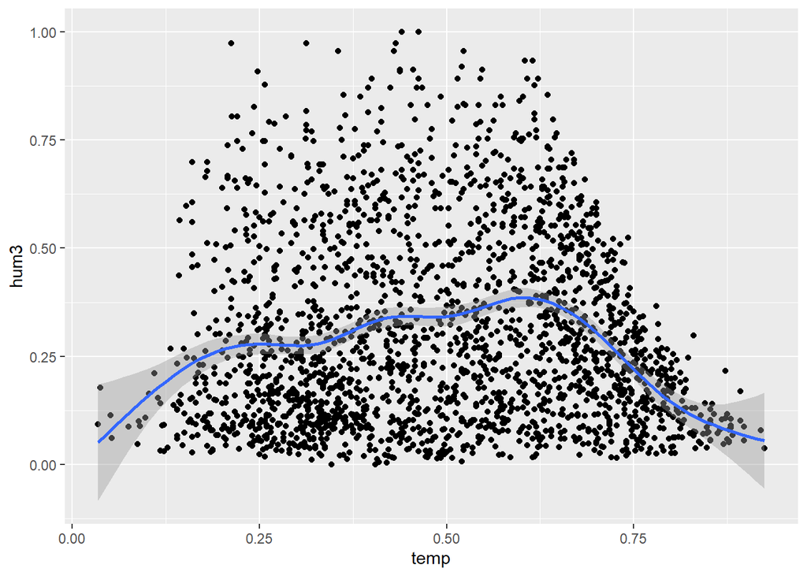

## Exogenous predictors

We need to check whether there is no relationship between the predictors of the model, and its errors.

```r
cov_res <- cov(predict(model2_mod), resid(model2_mod))
cov_res
```

```
## [1] 3.856117e-12
```

This value is practically equal to zero.

Next, we need to know whether the mean of the errors of the model are equal to zero.

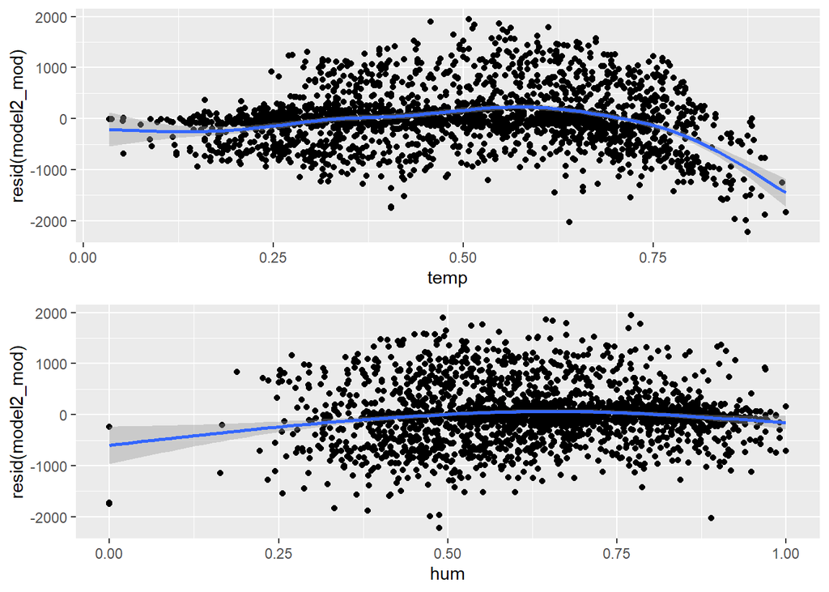

The first graph is not quite right, though the line only starts deviating from 0, in the latter part of the graph. There’s less data points there as well, so it makes sense. We can make do, though. The second graph is completely fine.

## Constant & finite variance

We need to find out whether the variance of the errors is constant over all levels of the predictor (homoscedasticity). That is shown in the first plot below. The second plot is similar, but it shows standardized residuals (or, more accurately, their square root).

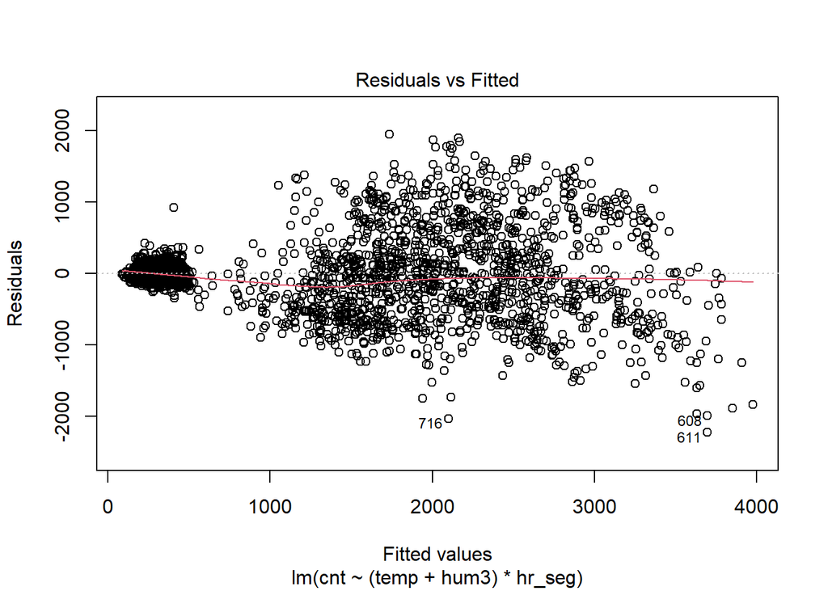

```r
# Residual plot.
model2_mod %>% plot(1)
```

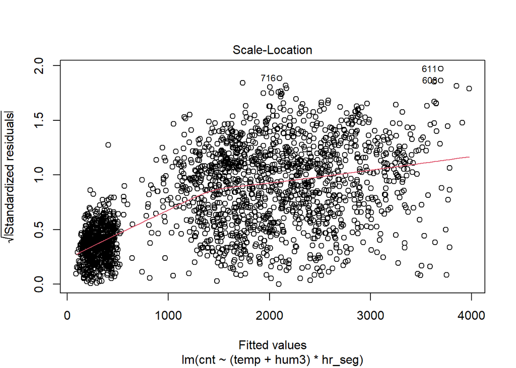

```r
model2_mod %>% plot(3)
```

## Independent errors

The errors should be independent. Now, we can check for clustering, though we have already manually clustered the data. We can check if that clustering was sufficient.

```r
ICCbare(data$temp, resid(model2_mod))
```

```
## [1] 0.1000876
```

```r
ICCbare(data$hum, resid(model2_mod))
```

```
## [1] 0.03000688
```

```r
ICCbare(data$hr_seg, resid(model2_mod))
```

```
## [1] -0.001371743
```

All ICC are close enough to 0 to conclude that there is no issue of dependence of errors.

## Normally distributed errors

The errors should be normally distributed. We can make a Q-Q plot to check whether that’s true.

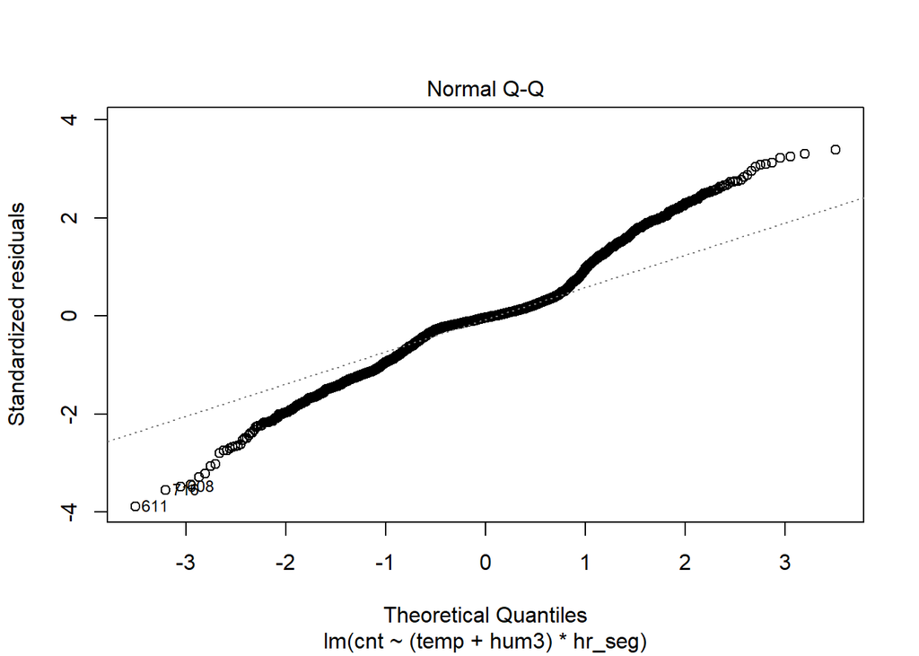

```r
plot(model2_mod, 2)
```

We want the errors to be as close to the dotted line as possible. It’s not looking to great, but it’s okay enough.

## Influential data points

We need to check whether the model contains any influential data points. That includes outliers and high-leverage observations. We can check the outliers first.

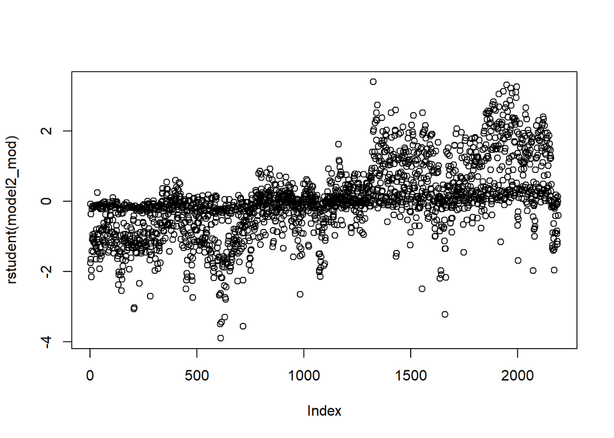

```r
plot(rstudent(model2_mod))
```

Again, the errors should be close to y = 0. And again, it doesn’t look to great, but most of the errors seem to be close to y = 0. Interestingly, the earlier outlying values seem to be below 0, while the later values seem to be above 0. It may be possible that the bike renting program started at the first day of this dataset, so it became more popular over time. There is no way to be sure, though.

Next, we need to measure Cook’s distance. Outliers are included in this measure as well, but since we checked those already, we really want to know about the high-leverage points.

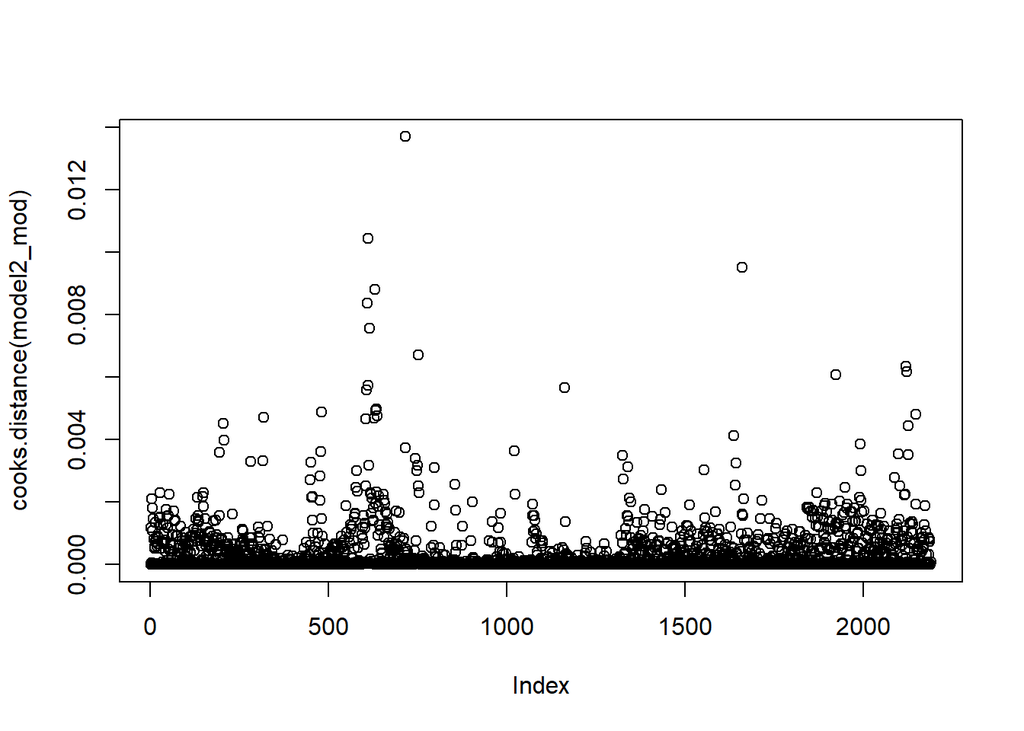

```r
plot(cooks.distance(model2_mod))            # Seems bad, but look at scale
```

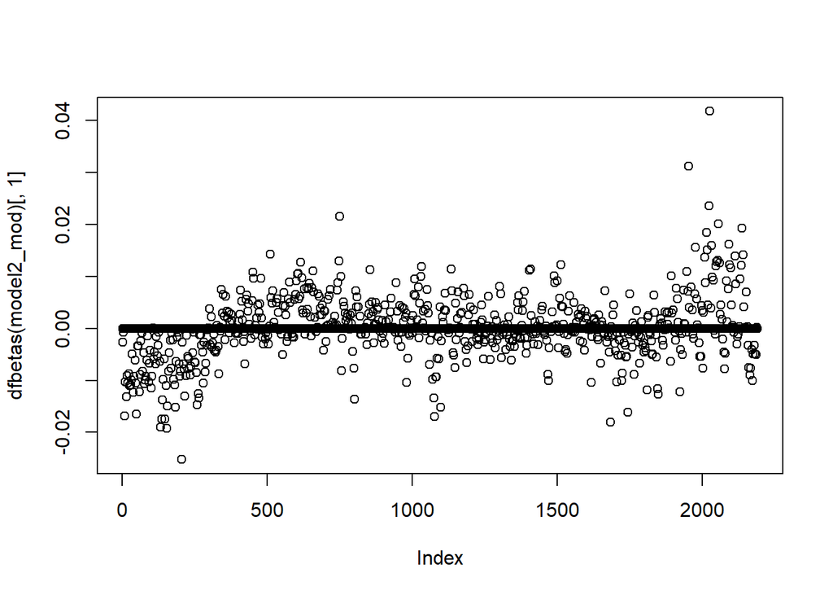

```r
plot(dfbetas(model2_mod)[,1])               # Seems good
```

Nowhere, Cook’s distance is high at all. So this assumption seems to be sufficiently met.